# E-Commerce Shipping Dataset :

### Product Shipment Delivered on time or not ; To Meet E-Commerce Customer Demand

The data contains the following information:

1. **ID** : ID Number of Customers.
2. **Warehouse block** : The Company have big Warehouse which is divided in to block such as A,B,C,D,E.
3. **Mode of shipment** :The Company Ships the products in multiple way such as Ship, Flight and Road.
4. **Customer care calls** : The number of calls made from enquiry for enquiry of the shipment.
5. **Customer rating** : The company has rated from every customer. 1 is the lowest (Worst), 5 is the highest (Best).
6. **Cost of the product** : Cost of the Product in US Dollars.
7. **Prior purchases** : The Number of Prior Purchase.
8. **Product importance** : The company has categorized the product in the various parameter such as low, medium, high.
9. **Gender** : Male and Female.
10. **Discount offered** : Discount offered on that specific product.
11. **Weight in gms** : It is the weight in grams.
12. **Reached on time** : It is the target variable, where 1 Indicates that the product has NOT reached on time and 0 indicates it has reached on time.

# Data Pre-processing

## Load & Describe Data

### Import library

```python
import numpy as np
import pandas as pd

#Visualization
import matplotlib.pyplot as plt
import matplotlib.style as style
style.use('fivethirtyeight') # use style fivethirtyeight
import seaborn as sns
from matplotlib import rcParams
import warnings
warnings.filterwarnings("ignore")

# Scaling
from sklearn.preprocessing import MinMaxScaler, StandardScaler

# Selection
from scipy.stats import chi2_contingency

# Splitting the data into Train and Test
from sklearn.model_selection import train_test_split

# Algorithm
from sklearn.linear_model import LogisticRegression
from sklearn.tree import DecisionTreeClassifier
from sklearn.svm import SVC
from sklearn.neighbors import KNeighborsClassifier
from sklearn.ensemble import RandomForestClassifier

# Evaluation metrics
from sklearn.metrics import accuracy_score, precision_score, recall_score, f1_score
from sklearn.metrics import roc_curve, auc, confusion_matrix, classification_report

# Hyperparameter tuning
from sklearn.model_selection import RandomizedSearchCV, GridSearchCV
```

### Import file

```python
df = pd.read_csv(r"C:\Users\HP\Downloads\Train.csv")
```

### Rename column target

```python
df.rename(columns={'Reached.on.Time_Y.N':'is_late'}, inplace=True)
df.head()
```

|  | ID | Warehouse_block | Mode_of_Shipment | Customer_care_calls | Customer_rating | Cost_of_the_Product | Prior_purchases | Product_importance | Gender | Discount_offered | Weight_in_gms | is_late |
| --- | --- | --- | --- | --- | --- | --- | --- | --- | --- | --- | --- | --- |
| 0 | 1 | D | Flight | 4 | 2 | 177 | 3 | low | F | 44 | 1233 | 1 |
| 1 | 2 | F | Flight | 4 | 5 | 216 | 2 | low | M | 59 | 3088 | 1 |
| 2 | 3 | A | Flight | 2 | 2 | 183 | 4 | low | M | 48 | 3374 | 1 |
| 3 | 4 | B | Flight | 3 | 3 | 176 | 4 | medium | M | 10 | 1177 | 1 |
| 4 | 5 | C | Flight | 2 | 2 | 184 | 3 | medium | F | 46 | 2484 | 1 |

Because of the target's name is too long, so we simplify the name to ease the next step.

### Get the shape of dataset

```python
df.shape
```

```
(10999, 12)
```

### Get list of columns

```python
df.columns
```

```
Index(['ID', 'Warehouse_block', 'Mode_of_Shipment', 'Customer_care_calls',
       'Customer_rating', 'Cost_of_the_Product', 'Prior_purchases',
       'Product_importance', 'Gender', 'Discount_offered', 'Weight_in_gms',
       'is_late'],
      dtype='object')
```

### Change all column names to lower case

```python
df.columns = df.columns.str.lower()
```

### Get dataset information

```python
df.info()
```

```
<class 'pandas.core.frame.DataFrame'>
RangeIndex: 10999 entries, 0 to 10998
Data columns (total 12 columns):
 #   Column               Non-Null Count  Dtype
---  ------               --------------  -----
 0   id                   10999 non-null  int64
 1   warehouse_block      10999 non-null  object
 2   mode_of_shipment     10999 non-null  object
 3   customer_care_calls  10999 non-null  int64
 4   customer_rating      10999 non-null  int64
 5   cost_of_the_product  10999 non-null  int64
 6   prior_purchases      10999 non-null  int64
 7   product_importance   10999 non-null  object
 8   gender               10999 non-null  object
 9   discount_offered     10999 non-null  int64
 10  weight_in_gms        10999 non-null  int64
 11  is_late              10999 non-null  int64
dtypes: int64(8), object(4)
memory usage: 1.0+ MB
```

```python
df.describe()
```

|  | id | customer_care_calls | customer_rating | cost_of_the_product | prior_purchases | discount_offered | weight_in_gms | is_late |
| --- | --- | --- | --- | --- | --- | --- | --- | --- |
| count | 10999.00000 | 10999.000000 | 10999.000000 | 10999.000000 | 10999.000000 | 10999.000000 | 10999.000000 | 10999.000000 |
| mean | 5500.00000 | 4.054459 | 2.990545 | 210.196836 | 3.567597 | 13.373216 | 3634.016729 | 0.596691 |
| std | 3175.28214 | 1.141490 | 1.413603 | 48.063272 | 1.522860 | 16.205527 | 1635.377251 | 0.490584 |
| min | 1.00000 | 2.000000 | 1.000000 | 96.000000 | 2.000000 | 1.000000 | 1001.000000 | 0.000000 |
| 25% | 2750.50000 | 3.000000 | 2.000000 | 169.000000 | 3.000000 | 4.000000 | 1839.500000 | 0.000000 |
| 50% | 5500.00000 | 4.000000 | 3.000000 | 214.000000 | 3.000000 | 7.000000 | 4149.000000 | 1.000000 |
| 75% | 8249.50000 | 5.000000 | 4.000000 | 251.000000 | 4.000000 | 10.000000 | 5050.000000 | 1.000000 |
| max | 10999.00000 | 7.000000 | 5.000000 | 310.000000 | 10.000000 | 65.000000 | 7846.000000 | 1.000000 |

**Based on the information above :**

1. Dataframe has 10999 rows and 12 columns.
2. No missing values are found.
3. There are only 2 data types, integer and object.
4. Classification target `is_late` and others we call features.

### Separate numeric & categorical column

```python
# Categorical data
categorical = ['warehouse_block','mode_of_shipment','product_importance', 'gender', 'is_late', 'customer_rating']
# Numerical data
numeric = ['customer_care_calls', 'cost_of_the_product', 'prior_purchases', 'discount_offered', 'weight_in_gms']
```

## Data Cleansing & Feature Engineering

#### Reload dataset

```python
df_dt = df.copy()
```

#### Identify missing values

```python
df_dt.isna().values.any() # Missing value detection
```

```
False
```

```python
df_dt.isna().sum()  # Calculate missing values
```

```
id                     0
warehouse_block        0
mode_of_shipment       0
customer_care_calls    0
customer_rating        0
cost_of_the_product    0
prior_purchases        0
product_importance     0
gender                 0
discount_offered       0
weight_in_gms          0
is_late                0
dtype: int64
```

Just for making sure that no missing values are found.

#### Identify duplicated values

```python
# Select all duplicate rows based on all columns
df_dt[df_dt.duplicated(keep=False)]
```

|  | id | warehouse_block | mode_of_shipment | customer_care_calls | customer_rating | cost_of_the_product | prior_purchases | product_importance | gender | discount_offered | weight_in_gms | is_late |
| --- | --- | --- | --- | --- | --- | --- | --- | --- | --- | --- | --- | --- |

```python
# Select all duplicate rows based on selected column
df_dt[df_dt.duplicated(subset=['id'],keep=False)] # Display all duplicated rows based on column 'id'
```

|  | id | warehouse_block | mode_of_shipment | customer_care_calls | customer_rating | cost_of_the_product | prior_purchases | product_importance | gender | discount_offered | weight_in_gms | is_late |
| --- | --- | --- | --- | --- | --- | --- | --- | --- | --- | --- | --- | --- |

Luckily, there is no duplicated value in the dataframe.

#### Identify outliers

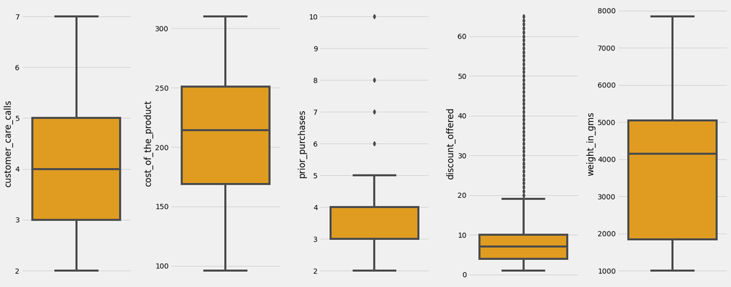

```python
# Identify using boxplot
plt.figure(figsize=(20,8))
for i in range(0,len(numeric)):
    plt.subplot(1, len(numeric), i+1)
    sns.boxplot(y=df_dt[numeric[i]], color='orange')
    plt.tight_layout()
```

```python
# Identify outlier using IQR
for col in numeric:

    # Menghitung nilai IQR
    Q1 = df_dt[col].quantile(0.25)
    Q3 = df_dt[col].quantile(0.75)
    IQR = Q3 - Q1

    # Define value
    nilai_min = df_dt[col].min()
    nilai_max = df_dt[col].max()
    lower_lim = Q1 - (1.5*IQR)
    upper_lim = Q3 + (1.5*IQR)

    # Identify low outlier

    if (nilai_min < lower_lim):
        print('Low outlier is found in column',col,'<', lower_lim,'\n')
        #display total low outlier
        print('Total of Low Outlier in column',col, ':', len(list(df_dt[df_dt[col] < lower_lim].index)),'\n')
    elif (nilai_max > upper_lim):
        print('High outlier is found in column',col,'>', upper_lim,'\n')
        #display total high outlier
        print('Total of High Outlier in column',col, ':', len(list(df_dt[df_dt[col] > upper_lim].index)),'\n')

    else:
        print('Outlier is not found in column',col,'\n')
```

```
Outlier is not found in column customer_care_calls

Outlier is not found in column cost_of_the_product

High outlier is found in column prior_purchases > 5.5

Total of High Outlier in column prior_purchases : 1003

High outlier is found in column discount_offered > 19.0

Total of High Outlier in column discount_offered : 2209

Outlier is not found in column weight_in_gms
```

We found outliers in `discount_offered` & `prior_purchases` with almost 30% of data.

```python
# We handle outlier with replace the value with upper_bound or lower_bound
for col in ['prior_purchases', 'discount_offered']:
    # Initiate Q1
    Q1 = df_dt[col].quantile(0.25)
    # Initiate Q3
    Q3 = df_dt[col].quantile(0.75)
    # Initiate IQR
    IQR = Q3 - Q1
    # Initiate lower_bound & upper_bound
    lower_bound = Q1 - (IQR * 1.5)
    upper_bound = Q3 + (IQR * 1.5)

    # Filtering outlier & replace with upper_bound or lower_bound
    df_dt[col] = np.where(df_dt[col] >= upper_bound,
                         upper_bound, df_dt[col])
    df_dt[col] = np.where(df_dt[col] <= lower_bound,
                         lower_bound, df_dt[col])
```

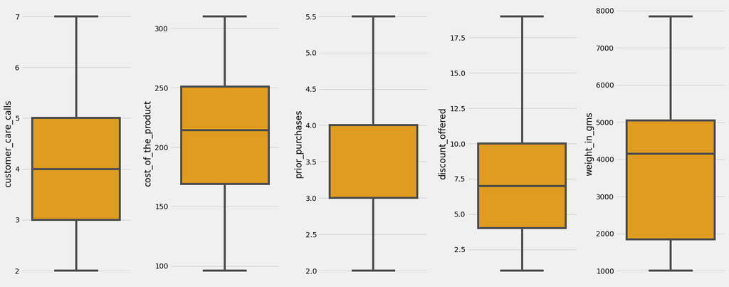

```python
# Identify using boxplot
plt.figure(figsize=(20,8))
for i in range(0,len(numeric)):
    plt.subplot(1, len(numeric), i+1)
    sns.boxplot(y=df_dt[numeric[i]], color='orange')
    plt.tight_layout()
```

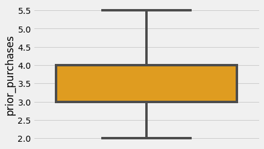

```python
sns.boxplot(y= df_dt['prior_purchases'], color = 'orange', orient = 'h');
```

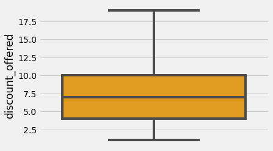

```python
sns.boxplot(y= df_dt['discount_offered'], color = 'orange', orient = 'h');
```

We didn't remove the outliers, but replacing with upper bound and lower bound. And we can see in the visualization above, there is no outliers detected.

#### Feature Transformation : Log transform

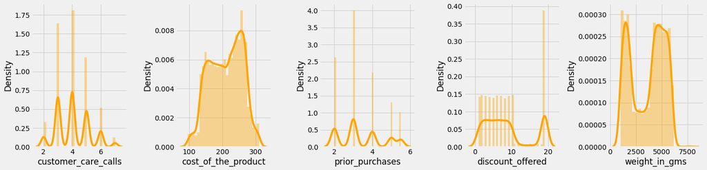

```python
# Check data distribution
plt.figure(figsize=(20,5))
for i in range(0,len(numeric)):
    plt.subplot(1, len(numeric), i+1)
    sns.distplot(df_dt[numeric[i]], color='orange')
    plt.tight_layout()
```

```python
# Apply log transformation
for col in numeric:
    df_dt[col] = (df_dt[col]+1).apply(np.log)
```

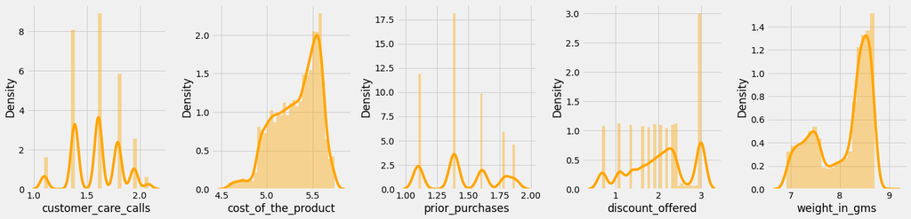

```python
# Visualize after log transformation
plt.figure(figsize=(20,5))
for i in range(0,len(numeric)):
    plt.subplot(1, len(numeric), i+1)
    sns.distplot(df_dt[numeric[i]], color='orange')
    plt.tight_layout()
```

#### Feature Scaling : Standardization

```python
# Apply standardization
for col in numeric:
    df_dt[col]= StandardScaler().fit_transform(df_dt[col].values.reshape(len(df_dt), 1))
```

```python
df_dt.describe()
```

|  | id | customer_care_calls | customer_rating | cost_of_the_product | prior_purchases | discount_offered | weight_in_gms | is_late |
| --- | --- | --- | --- | --- | --- | --- | --- | --- |
| count | 10999.00000 | 1.099900e+04 | 10999.000000 | 1.099900e+04 | 1.099900e+04 | 1.099900e+04 | 1.099900e+04 | 10999.000000 |
| mean | 5500.00000 | -6.375198e-15 | 2.990545 | -6.128706e-15 | -3.886356e-15 | -5.672726e-15 | 8.291496e-16 | 0.596691 |
| std | 3175.28214 | 1.000045e+00 | 1.413603 | 1.000045e+00 | 1.000045e+00 | 1.000045e+00 | 1.000045e+00 | 0.490584 |
| min | 1.00000 | -2.177630e+00 | 1.000000 | -3.086779e+00 | -1.387728e+00 | -1.947658e+00 | -2.073431e+00 | 0.000000 |
| 25% | 2750.50000 | -9.146463e-01 | 2.000000 | -7.773403e-01 | -2.636003e-01 | -6.234286e-01 | -9.814039e-01 | 0.000000 |
| 50% | 5500.00000 | 6.500001e-02 | 3.000000 | 1.892606e-01 | -2.636003e-01 | 5.582372e-02 | 4.788573e-01 | 1.000000 |
| 75% | 8249.50000 | 8.654293e-01 | 4.000000 | 8.428454e-01 | 6.083412e-01 | 5.160551e-01 | 8.317281e-01 | 1.000000 |
| max | 10999.00000 | 2.128413e+00 | 5.000000 | 1.708704e+00 | 1.633539e+00 | 1.380053e+00 | 1.622939e+00 | 1.000000 |

#### Feature Selection : Chi squared method

```python
# Selection for categorial feature
# Import module
from scipy.stats import chi2_contingency

category = ['warehouse_block','mode_of_shipment','product_importance',
            'gender','customer_rating']
chi2_check = []
# Iteration
for col in category:
    # If pvalue < 0.05
    if chi2_contingency(pd.crosstab(df_dt['is_late'], df_dt[col]))[1] < 0.05 :
        chi2_check.append('Reject Null Hypothesis')
    # If pvalue > 0.05
    else :
        chi2_check.append('Fail to Reject Null Hypothesis')

# Make the result into dataframe
res = pd.DataFrame(data = [category, chi2_check]).T
# Rename columns
res.columns = ['Column', 'Hypothesis']
res
```

|  | Column | Hypothesis |
| --- | --- | --- |
| 0 | warehouse_block | Fail to Reject Null Hypothesis |
| 1 | mode_of_shipment | Fail to Reject Null Hypothesis |
| 2 | product_importance | Reject Null Hypothesis |
| 3 | gender | Fail to Reject Null Hypothesis |
| 4 | customer_rating | Fail to Reject Null Hypothesis |

```python
# Adjusted P-Value use the Bonferroni-adjusted method

# Initiate empty dictionary
check = {}
# Iteration for product_importance column
for i in res[res['Hypothesis'] == 'Reject Null Hypothesis']['Column']:
    # One hot encoding product_importance column
    dummies = pd.get_dummies(df_dt[i])
    # Initiate Bonferroni-adjusted formula
    bon_p_value = 0.05/df_dt[i].nunique()
    for series in dummies:
        if chi2_contingency(pd.crosstab(df_dt['is_late'], dummies[series]))[1] < bon_p_value:
            check['{}-{}'.format(i, series)] = 'Reject Null Hypothesis'
        else :
            check['{}-{}'.format(i, series)] = 'Fail to Reject Null Hypothesis'
# Make the result into dataframe
res_chi_ph = pd.DataFrame(data=[check.keys(), check.values()]).T
# Rename the columns
res_chi_ph.columns = ['Pair', 'Hypothesis']
res_chi_ph
```

|  | Pair | Hypothesis |
| --- | --- | --- |
| 0 | product_importance-high | Reject Null Hypothesis |
| 1 | product_importance-low | Fail to Reject Null Hypothesis |
| 2 | product_importance-medium | Fail to Reject Null Hypothesis |

From the result above, `product_importance` with **high** category has a correlation with our target.

#### Feature Encoding : One hot encoding

```python
# one hot encoding feature product_importance and keep high category
onehots = pd.get_dummies(df_dt['product_importance'], prefix = 'product_importance')
df_dt = df_dt.join(onehots)

# drop all categorical columns & 'id, except product_importance_high
df_dt.drop(columns=['warehouse_block','gender','mode_of_shipment',
                   'product_importance', 'product_importance_low',
                   'product_importance_medium','id'], inplace = True)
# check dataframe after encoding
df_dt.info()
```

```
<class 'pandas.core.frame.DataFrame'>
RangeIndex: 10999 entries, 0 to 10998
Data columns (total 8 columns):
 #   Column                   Non-Null Count  Dtype
---  ------                   --------------  -----
 0   customer_care_calls      10999 non-null  float64
 1   customer_rating          10999 non-null  int64
 2   cost_of_the_product      10999 non-null  float64
 3   prior_purchases          10999 non-null  float64
 4   discount_offered         10999 non-null  float64
 5   weight_in_gms            10999 non-null  float64
 6   is_late                  10999 non-null  int64
 7   product_importance_high  10999 non-null  uint8
dtypes: float64(5), int64(2), uint8(1)
memory usage: 612.4 KB
```

## Exploratory Data Analysis (EDA)

```python
# Copy dataset
df_eda = df.copy()
```

### Target Visualization

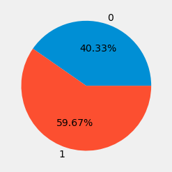

```python
delay = pd.DataFrame(df_eda.groupby(['is_late'])['id'].count()/len(df_eda)).reset_index()
plt.pie(delay['id'],labels=delay['is_late'],autopct='%.2f%%');
```

The class of target looks balance.

### Descriptive Statistic

#### Categorical values

```python
# for categorical column
for col in categorical:
    print('Value count kolom', col, ':')
    print(df_eda[col].value_counts())
    print()
```

```
Value count kolom warehouse_block :
F    3666
D    1834
A    1833
B    1833
C    1833
Name: warehouse_block, dtype: int64

Value count kolom mode_of_shipment :
Ship      7462
Flight    1777
Road      1760
Name: mode_of_shipment, dtype: int64

Value count kolom product_importance :
low       5297
medium    4754
high       948
Name: product_importance, dtype: int64

Value count kolom gender :
F    5545
M    5454
Name: gender, dtype: int64

Value count kolom is_late :
1    6563
0    4436
Name: is_late, dtype: int64

Value count kolom customer_rating :
3    2239
1    2235
4    2189
5    2171
2    2165
Name: customer_rating, dtype: int64
```

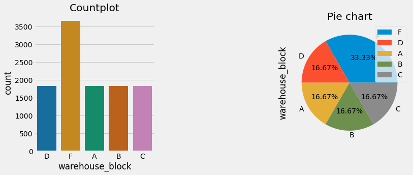

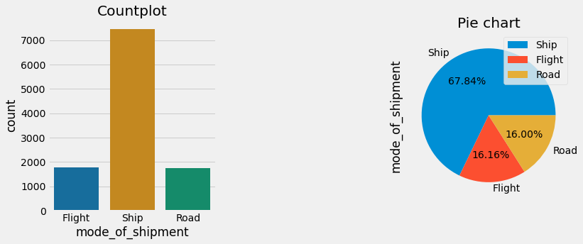

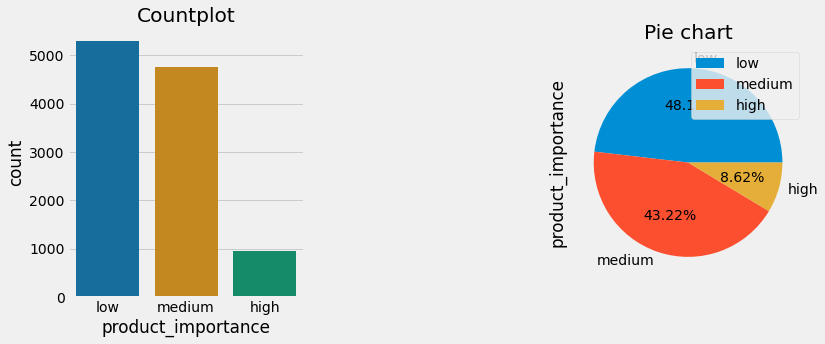

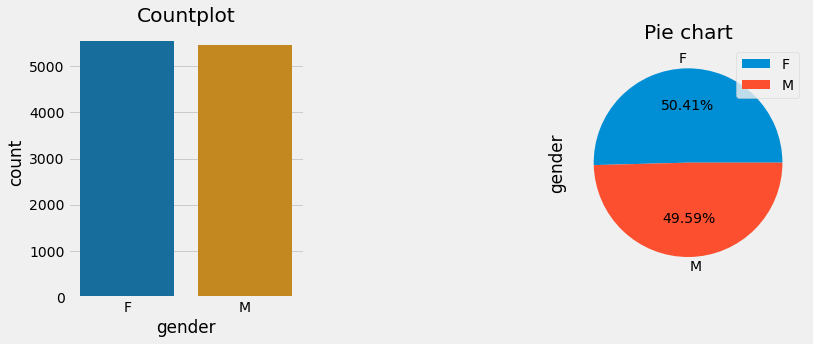

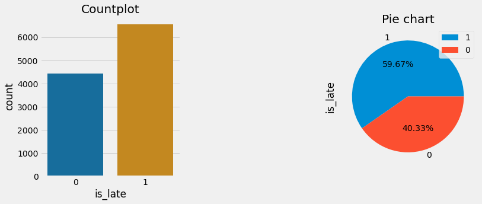

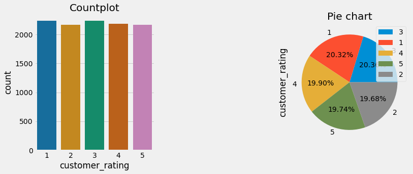

```python
# Plot categorical columns
for col in categorical:
    plt.figure(figsize=(15, 5))

    plt.subplot(141);
    sns.countplot(df_eda[col], palette = 'colorblind', orient='v');
    plt.title('Countplot')
    plt.tight_layout();


    plt.subplot(143);
    df_eda[col].value_counts().plot.pie(autopct='%1.2f%%');
    plt.title('Pie chart')
    plt.legend()
```

**Summary :**

- **Warehouse_Block** has 5 unique values and dominated with `Warehouse_block_f`.
- **Mode_of_Shipment** has 3 unique values and mostly used ship.
- **Product_importance** has 3 unique values and mostly priority of products are low.
- Female customers are often shopping than male.

#### Numeric values

```python
df_eda[numeric].describe()
```

|  | customer_care_calls | cost_of_the_product | prior_purchases | discount_offered | weight_in_gms |
| --- | --- | --- | --- | --- | --- |
| count | 10999.000000 | 10999.000000 | 10999.000000 | 10999.000000 | 10999.000000 |
| mean | 4.054459 | 210.196836 | 3.567597 | 13.373216 | 3634.016729 |
| std | 1.141490 | 48.063272 | 1.522860 | 16.205527 | 1635.377251 |
| min | 2.000000 | 96.000000 | 2.000000 | 1.000000 | 1001.000000 |
| 25% | 3.000000 | 169.000000 | 3.000000 | 4.000000 | 1839.500000 |
| 50% | 4.000000 | 214.000000 | 3.000000 | 7.000000 | 4149.000000 |
| 75% | 5.000000 | 251.000000 | 4.000000 | 10.000000 | 5050.000000 |
| max | 7.000000 | 310.000000 | 10.000000 | 65.000000 | 7846.000000 |

**Summary :**

- Distribution of **customer_care_calls**, **Customer_rating**, **Cost_of_the_Product**, **Prior_purchases** look normal, beacuse the mean and the median are close, while **discount_offered** and **weight_in_grams** are indicated skewed.

#### Correlation Heatmap

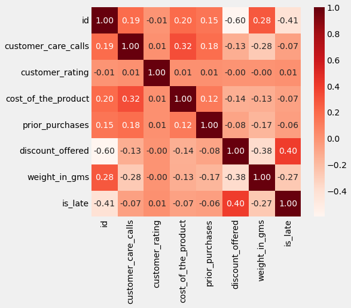

```python
plt.figure(figsize=(7,6));
sns.heatmap(df_eda.corr(), annot = True, fmt = '.2f', cmap = 'Reds');
```

Based on the *Correlation heatmap* above :

1. Target *is_late* has a moderate positive correlation with *discount_offered* & weak negative correlation with *weight_in_gms*.
2. Feature *customer_care_calss* has a weak positive correlation with *cost_of_the_product* and negative correlation with *weight_in_gms*.
3. Feature *discount_offered* has a moderate negative correlation with *weight_in_gms*.

#### Categorical - Categorical

##### Based on Gender

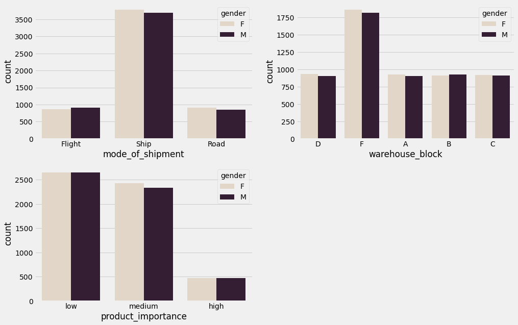

```python
i=1
plt.figure(figsize=(15,10))
for col in ['mode_of_shipment', 'warehouse_block', 'product_importance']:
    plt.subplot(2,2,i)
    sns.countplot(df_eda[col], hue=df_eda['gender'], palette="ch:.25")
    i+=1
```

**Summary :**

- Total parcels of female customers in the warehouse_block are more dominant than male customers, except in warehouse_block B.

##### Based on Product Importance

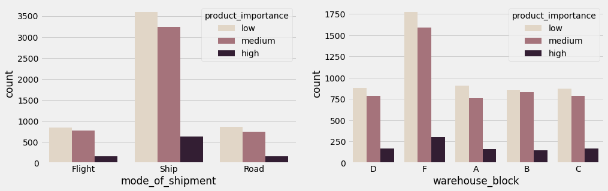

```python
i=1
plt.figure(figsize=(15,10))
for col in ['mode_of_shipment', 'warehouse_block']:
    plt.subplot(2,2,i)
    sns.countplot(df_eda[col], hue=df_eda['product_importance'], palette="ch:.25")
    i+=1
```

**Summary :**

- Mostly high & low priority parcels used ship.

##### Warehouse block - Mode of Shipment

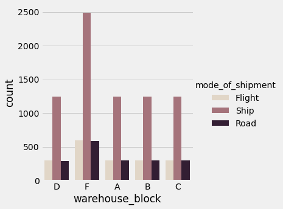

```python
sns.catplot(x="warehouse_block", kind="count", hue='mode_of_shipment',
            palette="ch:.25", data=df_eda);
```

##### Based on target 'is_late'

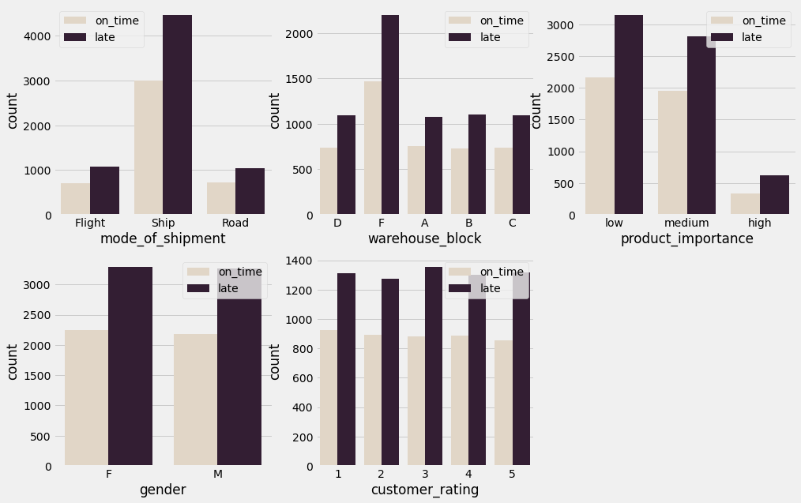

```python
i=1
plt.figure(figsize=(15,10))
for col in ['mode_of_shipment', 'warehouse_block', 'product_importance',
            'gender','customer_rating']:
    plt.subplot(2,3,i)
    sns.countplot(df_eda[col], hue=df_eda['is_late'], palette="ch:.25")
    i+=1
    plt.legend(['on_time','late']);
```

**Summary :**

- Most of parcels are stored in warehouse_block F.
- The ship contributes the most late delivery.
- Most of parcels in all shipment priority are delivered late.

# Machine Learning Modelling & Evaluation

### Separate feature & target column

```python
# Inititate feature & target
X = df_dt.drop(columns = 'is_late')
y = df_dt['is_late']
```

### Split train & test data

```python
# Split Train & Test Data
Xtrain, Xtest, ytrain, ytest = train_test_split(X, y, test_size=0.30, random_state=42)
```

### Fit & Evaluation Model

```python
# Create function to fit model & model evaluation
def fit_evaluation(Model, Xtrain, ytrain, Xtest, ytest):
    model = Model # initiate model
    model.fit(Xtrain, ytrain) # fit the model
    y_pred = model.predict(Xtest)
    y_pred_train = model.predict(Xtrain)
    train_score = model.score(Xtrain, ytrain) # Train Accuracy
    test_score = model.score(Xtest, ytest)    # Test Accuracy
    fpr, tpr, thresholds = roc_curve(ytest, y_pred, pos_label=1)
    AUC = auc(fpr, tpr) # AUC
    return round(train_score,2), round(test_score,2), round(precision_score(ytest, y_pred),2), \
           round(recall_score(ytrain, y_pred_train),2),round(recall_score(ytest, y_pred),2), \
           round(f1_score(ytest, y_pred),2), round(AUC,2)
```

#### Default Parameter

```python
# Inititate algorithm
lr = LogisticRegression(random_state=42)
dt = DecisionTreeClassifier(random_state=42)
rf = RandomForestClassifier(random_state=42)
knn = KNeighborsClassifier(n_neighbors=5)
svc = SVC(random_state=42)

# Create function to make the result as dataframe
def model_comparison_default(X,y):

    # Logistic Regression
    lr_train_score, lr_test_score, lr_pr, lrtr_re, lrte_re, lr_f1, lr_auc = fit_evaluation(
        lr, Xtrain, ytrain, Xtest, ytest)
    # Decision Tree
    dt_train_score, dt_test_score, dt_pr, dttr_re, dtte_re, dt_f1, dt_auc = fit_evaluation(
        dt, Xtrain, ytrain, Xtest, ytest)
    # Random Forest
    rf_train_score, rf_test_score, rf_pr, rftr_re, rfte_re, rf_f1, rf_auc = fit_evaluation(
        rf, Xtrain, ytrain, Xtest, ytest)
    # KNN
    knn_train_score, knn_test_score, knn_pr, knntr_re, knnte_re, knn_f1, knn_auc = fit_evaluation(
        knn, Xtrain, ytrain, Xtest, ytest)
    # SVC
    svc_train_score, svc_test_score, svc_pr, svctr_re, svcte_re, svc_f1, svc_auc = fit_evaluation(
        svc, Xtrain, ytrain, Xtest, ytest)


    models = ['Logistic Regression','Decision Tree','Random Forest',
             'KNN','SVC']
    train_score = [lr_train_score, dt_train_score, rf_train_score,
                   knn_train_score, svc_train_score]
    test_score = [lr_test_score, dt_test_score, rf_test_score,
                  knn_test_score, svc_test_score]
    precision = [lr_pr, dt_pr, rf_pr, knn_pr, svc_pr]
    recall_train = [lrtr_re, dttr_re, rftr_re, knntr_re, svctr_re]
    recall_test = [lrte_re, dtte_re, rfte_re, knnte_re, svcte_re]
    f1 = [lr_f1, dt_f1, rf_f1, knn_f1, svc_f1]
    auc = [lr_auc, dt_auc, rf_auc, knn_auc, svc_auc]

    model_comparison = pd.DataFrame(data=[models, train_score, test_score,
                                          precision, recall_train, recall_test,
                                          f1,auc]).T.rename({0: 'Model',
                                                             1: 'Accuracy_Train',
                                                             2: 'Accuracy_Test',
                                                             3: 'Precision',
                                                             4: 'Recall_Train',
                                                             5: 'Recall_Test',
                                                             6: 'F1 Score',
                                                             7: 'AUC'
                                                                                  }, axis=1)

    return model_comparison
```

```python
model_comparison_default(X,y)
```

|  | Model | Accuracy_Train | Accuracy_Test | Precision | Recall_Train | Recall_Test | F1 Score | AUC |
| --- | --- | --- | --- | --- | --- | --- | --- | --- |
| 0 | Logistic Regression | 0.63 | 0.63 | 0.67 | 0.75 | 0.75 | 0.71 | 0.6 |
| 1 | Decision Tree | 1.0 | 0.66 | 0.72 | 1.0 | 0.71 | 0.71 | 0.64 |
| 2 | Random Forest | 1.0 | 0.67 | 0.76 | 1.0 | 0.66 | 0.71 | 0.67 |
| 3 | KNN | 0.76 | 0.64 | 0.72 | 0.77 | 0.67 | 0.69 | 0.64 |
| 4 | SVC | 0.68 | 0.66 | 0.88 | 0.52 | 0.51 | 0.65 | 0.7 |

From the result above, only **Logistic Regression and SVC which are neither overfitting nor underfiting**. Logistic Regression has the highest recall. Let's see with tuned parameter.

### Hyperparameter

#### Logistic Regression

```python
# List Hyperparameters
penalty = ['l2','l1','elasticnet']
C = [0.0001, 0.001, 0.002] # Inverse of regularization strength; smaller values specify stronger regularization.
hyperparameters = dict(penalty=penalty, C=C)

# Inisiasi model
logres = LogisticRegression(random_state=42) # Init Logres dengan Gridsearch, cross validation = 5
model = RandomizedSearchCV(logres, hyperparameters, cv=5, random_state=42,  scoring='recall')

# Fitting Model & Evaluation
model.fit(Xtrain, ytrain)
y_pred = model.predict(Xtest)
model.best_estimator_
```

```
LogisticRegression(C=0.0001, random_state=42)
```

#### Decision Tree

```python
# Let's do hyperparameter tuning using RandomizesearchCV

# Hyperparameter lists to be tested
max_depth = list(range(1,10))
min_samples_split = list(range(5,10))
min_samples_leaf = list(range(5,15))
max_features = ['auto', 'sqrt', 'log2']
criterion = ['gini','entropy']
splitter = ['best','random']

# Initiate hyperparameters
hyperparameters = dict(max_depth=max_depth,
                       min_samples_split=min_samples_split,
                       min_samples_leaf=min_samples_leaf,
                       max_features=max_features,
                       criterion = criterion,
                       splitter = splitter)

# Initiate model
dt_tun = DecisionTreeClassifier(random_state=42)
model = RandomizedSearchCV(dt_tun, hyperparameters, cv=10, scoring='recall',random_state=42)
model.fit(Xtrain, ytrain)
y_pred_tun = model.predict(Xtest)
model.best_estimator_
```

```
DecisionTreeClassifier(criterion='entropy', max_depth=4, max_features='sqrt',
                       min_samples_leaf=12, min_samples_split=6,
                       random_state=42)
```

#### Random Forest

```python
# Initiate hyperparameters
params = {'max_depth':[50],'n_estimators':[100,150],
          'criterion':['gini', 'entropy']}
# Initiate model
model = GridSearchCV(estimator=RandomForestClassifier(random_state=42),
                     param_grid=params,scoring='recall', cv=5)
# Fit model
model.fit(Xtrain,ytrain)
y_pred = model.predict(Xtest)
# Get best estimator
model.best_estimator_
```

```
RandomForestClassifier(max_depth=50, random_state=42)
```

#### KNN

```python
#List Hyperparameters that we want to tune.
leaf_size = list(range(1,50))
n_neighbors = list(range(1,30))
p=[1,2]

#Convert to dictionary
hyperparameters = dict(leaf_size=leaf_size, n_neighbors=n_neighbors, p=p)

#Create new KNN object
KNN_2 = KNeighborsClassifier()

#Use RandomizedSearchCV
clf = RandomizedSearchCV(KNN_2, hyperparameters, cv=10, scoring = 'recall')

#Fit the model
best_model = clf.fit(X,y)
# Get best estimator
clf.best_estimator_
```

[output not shown]

#### SVC

```python
# Hyperparameter lists to be tested
kernel = ['linear', 'poly', 'rbf', 'sigmoid']
C = [0.0001, 0.001, 0.002]
gamma = ['scale', 'auto']

#Convert to dictionary
hyperparameters = dict(kernel=kernel, C=C, gamma=gamma)

# Initiate model
svc = SVC(random_state=42)
model = RandomizedSearchCV(svc, hyperparameters, cv=5, random_state=42,
                           scoring='recall')

# Fitting Model & Evaluation
model.fit(Xtrain, ytrain)
y_pred = model.predict(Xtest)
model.best_estimator_
```

```
SVC(C=0.0001, kernel='linear', random_state=42)
```

#### Tuned Parameter

```python
# Inititate best estimator
lr_tune = LogisticRegression(C=0.0001, random_state=42)
dt_tune = DecisionTreeClassifier(criterion='entropy', max_depth=4, max_features='sqrt',
                       min_samples_leaf=12, min_samples_split=6,
                       random_state=42)
rf_tune = RandomForestClassifier(max_depth=50, random_state=42)

knn_tune = KNeighborsClassifier(leaf_size=24, n_neighbors=3, p=1)

svc_tune = SVC(C=0.0001, kernel='linear', random_state=42)

# Create function to make the result as dataframe
def model_comparison_tuned(X,y):

    # Logistic Regression
    lr_train_score, lr_test_score, lr_pr, lrtr_re, lrte_re, lr_f1, lr_auc = fit_evaluation(
        lr_tune, Xtrain, ytrain, Xtest, ytest)
    # Decision Tree
    dt_train_score, dt_test_score, dt_pr, dttr_re, dtte_re, dt_f1, dt_auc = fit_evaluation(
        dt_tune, Xtrain, ytrain, Xtest, ytest)
    # Random Forest
    rf_train_score, rf_test_score, rf_pr, rftr_re, rfte_re, rf_f1, rf_auc = fit_evaluation(
        rf_tune, Xtrain, ytrain, Xtest, ytest)
    # KNN
    knn_train_score, knn_test_score, knn_pr, knntr_re, knnte_re, knn_f1, knn_auc = fit_evaluation(
        knn_tune, Xtrain, ytrain, Xtest, ytest)
    # SVC
    svc_train_score, svc_test_score, svc_pr, svctr_re, svcte_re, svc_f1, svc_auc = fit_evaluation(
        svc_tune, Xtrain, ytrain, Xtest, ytest)


    models = ['Logistic Regression','Decision Tree','Random Forest',
             'KNN','SVC']
    train_score = [lr_train_score, dt_train_score, rf_train_score,
                   knn_train_score, svc_train_score]
    test_score = [lr_test_score, dt_test_score, rf_test_score,
                  knn_test_score, svc_test_score]
    precision = [lr_pr, dt_pr, rf_pr, knn_pr, svc_pr]
    recall_train = [lrtr_re, dttr_re, rftr_re, knntr_re, svctr_re]
    recall_test = [lrte_re, dtte_re, rfte_re, knnte_re, svcte_re]
    f1 = [lr_f1, dt_f1, rf_f1, knn_f1, svc_f1]
    auc = [lr_auc, dt_auc, rf_auc, knn_auc, svc_auc]

    model_comparison = pd.DataFrame(data=[models, train_score, test_score,
                                          precision, recall_train, recall_test,
                                          f1,auc]).T.rename({0: 'Model',
                                                             1: 'Accuracy_Train',
                                                             2: 'Accuracy_Test',
                                                             3: 'Precision',
                                                             4: 'Recall_Train',
                                                             5: 'Recall_Test',
                                                             6: 'F1 Score',
                                                             7: 'AUC'
                                                                                  }, axis=1)

    return model_comparison
```

```python
model_comparison_tuned(X,y)
```

|  | Model | Accuracy_Train | Accuracy_Test | Precision | Recall_Train | Recall_Test | F1 Score | AUC |
| --- | --- | --- | --- | --- | --- | --- | --- | --- |
| 0 | Logistic Regression | 0.59 | 0.6 | 0.6 | 1.0 | 1.0 | 0.75 | 0.5 |
| 1 | Decision Tree | 0.67 | 0.68 | 0.8 | 0.62 | 0.62 | 0.7 | 0.69 |
| 2 | Random Forest | 1.0 | 0.67 | 0.76 | 1.0 | 0.66 | 0.71 | 0.67 |
| 3 | KNN | 0.81 | 0.65 | 0.72 | 0.82 | 0.69 | 0.7 | 0.64 |
| 4 | SVC | 0.59 | 0.6 | 0.6 | 1.0 | 1.0 | 0.75 | 0.5 |

Decision Tree algorithm with hyper-parameter tuning has a good balance between its score, also neither underfitting nor overfitting.

### Confusion matrix

```python
from sklearn.metrics import confusion_matrix
import matplotlib.pyplot as plt
import seaborn as sns

def get_confusion_matrix(model, X_train, y_train, X_test, y_test, labels=None):
    # Train the model on the training data
    model.fit(X_train, y_train)

    # Make predictions on the test data
    y_pred = model.predict(X_test)

    # Create confusion matrix
    cm = confusion_matrix(y_test, y_pred)

    # Set display labels
    if labels is None:
        labels = ['Negative', 'Positive']

    # Plot the confusion matrix using Seaborn heatmap
    plt.figure(figsize=(3, 3))
    sns.heatmap(cm, annot=True, cmap='Blues', fmt='g', xticklabels=labels, yticklabels=labels)
    plt.xlabel('Predicted labels')
    plt.ylabel('True labels')
    plt.title('Confusion Matrix')
    plt.show()
```

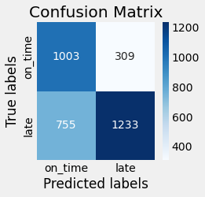

```python
# After hyperparameter tuning
get_confusion_matrix(dt_tune, Xtrain, ytrain, Xtest, ytest,labels=['on_time','late'])
```

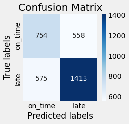

```python
# Before hyperparameter tuning
get_confusion_matrix(dt, Xtrain, ytrain, Xtest, ytest,labels=['on_time','late'])
```

### Feature Importance

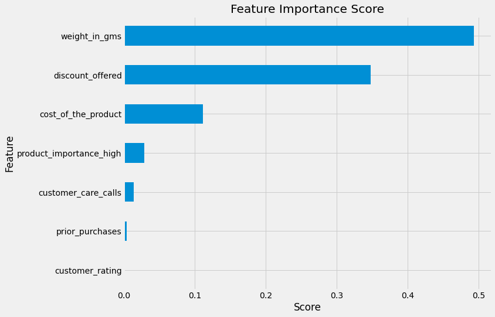

```python
feat_importances = pd.Series(dt_tune.feature_importances_, index=X.columns)
ax = feat_importances.nlargest(25).plot(kind='barh', figsize=(10, 8))
ax.invert_yaxis()

plt.xlabel('Score');
plt.ylabel('Feature');
plt.title('Feature Importance Score');
```

**Recommendation for E-Commerce :**

- The operation team should add more manpower when there is a sale program, especially for the discount more than 10% and the parcel weight is 1 - 4 Kg.
- The parcel should not be centralized in the warehouse block F, so that the handling is not too crowded which can cause the late shipment.
- Adding more features can imporve model performance, such as delivery time estimation, delivery date, customer address, and courier.